# Lecture 03

## 5.1.0 Filter and subset `wormSporeDose_summary.df`

1. Filter `wormSporeDose_summary.df` from section **2.2.0** to remove all zero `sporeDose` values.
2. Join this with the spore metadata in `spore_metadata.df`
3. Sort the result alphabetically by spore species name and also increasing dose.

Save the results of these steps in `wormSporeDose_updated.df`.

```r
# Open and save the spore metadata to an object. You probably did this already but let's redo it just in case...
spore_metadata.df <-

  read_tsv("data/spore_info.txt", col_names = TRUE) %>%

  # Convert the spore strain information to a factor. Can you do this on import?
  mutate(spore.strain = as.factor(spore.strain))
# Check on the structure of spore_metadata.df
str(spore_metadata.df)
```

```
## tibble [7 x 5] (S3: tbl_df/tbl/data.frame)
##  $ spore.strain             : Factor w/ 7 levels "AWRm78","Cider",..: 3 4 5 6 1 2 7
##  $ spore.species            : chr [1:7] "N. parisii" "N. ausubeli" "N. ironsii" "N. ferruginous" ...
##  $ infection.location       : chr [1:7] "intestine" "intestine" "intestine" "epidermis" ...
##  $ original.nematode.species: chr [1:7] "C. elegans" "C. briggsae" "C. briggsae" "C. elegans" ...
##  $ original.location        : chr [1:7] "France" "India" "Hawaii, USA" "France" ...
```

```r
str(wormSporeDose_summary.df, give.attr = FALSE)
```

```
## gropd_df [26 x 3] (S3: grouped_df/tbl_df/tbl/data.frame)
##  $ sporeStrain     : Factor w/ 11 levels "AWRm78","ERTm1",..: 1 2 2 2 2 3 3 3 3 4 ...
##  $ sporeDose       : num [1:26] 3.5 0 0.75 1.25 1.5 0 0.5 1.25 1.5 0 ...
##  $ groupMeanEmbryos: num [1:26] 11.4 20.3 18.5 14.4 15 ...
```

Proceed with our join step and sorting

```r
# Save the results of our filtering and joining
wormSporeDose_updated.df <-

  # Start by passing the summary data
  wormSporeDose_summary.df %>%

  # Filter the spore dose values
  filter(sporeDose > 0) %>%

  # Join this with the spore metadata
  inner_join(., y = spore_metadata.df, by = c("sporeStrain" = "spore.strain")) %>%

  # Sort the data by spore species and then by spore dose
  arrange(spore.species, sporeStrain, sporeDose)

wormSporeDose_updated.df
```

| sporeStrain | sporeDose | groupMeanEmbryos | spore.species | infection.location | original.nematode.species | original.location |
| --- | --- | --- | --- | --- | --- | --- |
| ERTm2 | 0.500 | 9.921875 | N. ausubeli | intestine | C. briggsae | India |
| ERTm2 | 1.250 | 1.250000 | N. ausubeli | intestine | C. briggsae | India |
| ERTm2 | 1.500 | 2.111111 | N. ausubeli | intestine | C. briggsae | India |
| LUAm1 | 10.000 | 11.286667 | N. ferruginous | epidermis | C. elegans | France |
| LUAm1 | 15.000 | 8.755102 | N. ferruginous | epidermis | C. elegans | France |
| LUAm1 | 20.000 | 7.700000 | N. ferruginous | epidermis | C. elegans | France |
| LUAm3 | 10.000 | 12.340000 | N. ferruginous | epidermis | C. elegans | France |
| AWRm78 | 3.500 | 11.393333 | N. ironsii | intestine | C. elegans | Ontario, Canada |
| ERTm5 | 0.200 | 16.340000 | N. ironsii | intestine | C. briggsae | Hawaii, USA |
| ERTm5 | 0.350 | 16.200000 | N. ironsii | intestine | C. briggsae | Hawaii, USA |

[output cut: 7 more lines]

### 5.1.1 How many rows in `wormSporeDose_summary.df` had a spore dose of zero?

Let’s step back in our process and ask the question of how many rows of data are actually removed in the process from `wormSporeDose_summary.df`.

```r
wormSporeDose_summary.df %>%

# Use filter to pull out the rows we want to view
filter(sporeDose == 0)
```

| sporeStrain | sporeDose | groupMeanEmbryos |
| --- | --- | --- |
| ERTm1 | 0 | 20.27463 |
| ERTm2 | 0 | 19.35821 |
| ERTm5 | 0 | 17.96389 |
| LUAm1 | 0 | 17.94635 |

So it appears that 4 groups were lost to our `filter()` call and an additional 5 were removed during the `inner_join()` process!

## 5.2.0 Convert `gapminder_wide` to a long format

Read in the `gapminder_wide.csv`. What rules of tidy data does it break? Transform the dataset to the format below.

| continent | country | year | lifeExp | pop | gdpPercap |
| --- | --- | --- | --- | --- | --- |
| Asia | Afghanistan | 1952 | 28.801 | 8425333 | 779.4453 |
| Asia | Afghanistan | 1957 | 30.332 | 9240934 | 820.8530 |
| Asia | Afghanistan | 1962 | 31.997 | 10267083 | 853.1007 |
| Asia | Afghanistan | 1967 | 34.020 | 11537966 | 836.1971 |
| Asia | Afghanistan | 1972 | 36.088 | 13079460 | 739.9811 |
| Asia | Afghanistan | 1977 | 38.438 | 14880372 | 786.1134 |

1. How many rows do you have?
2. Save the newly reshaped document as `gapminder_long`

Reshape `gapminder_wide` into a long, cleansed format. **BEFORE** you start writing any code, **IDENTIFY** the formatting deficiencies and then **PLAN** ahead what you want to achieve.

```r
# read gapminder_wide.csv
gapminder_wide <- read_csv("data/gapminder_wide.csv")
# Take a peek at the data
head(gapminder_wide)
```

| continent | country | gdpPercap_1952 | gdpPercap_1957 | gdpPercap_1962 | gdpPercap_1967 | gdpPercap_1972 | gdpPercap_1977 | gdpPercap_1982 | gdpPercap_1987 | gdpPercap_1992 | gdpPercap_1997 | gdpPercap_2002 | gdpPercap_2007 | lifeExp_1952 | lifeExp_1957 | lifeExp_1962 | lifeExp_1967 | lifeExp_1972 | lifeExp_1977 | lifeExp_1982 | lifeExp_1987 | lifeExp_1992 | lifeExp_1997 | lifeExp_2002 | lifeExp_2007 | pop_1952 | pop_1957 | pop_1962 | pop_1967 | … |
| --- | --- | --- | --- | --- | --- | --- | --- | --- | --- | --- | --- | --- | --- | --- | --- | --- | --- | --- | --- | --- | --- | --- | --- | --- | --- | --- | --- | --- | --- | --- |
| Africa | Algeria | 2449.0082 | 3013.9760 | 2550.8169 | 3246.9918 | 4182.6638 | 4910.4168 | 5745.1602 | 5681.3585 | 5023.2166 | 4797.2951 | 5288.0404 | 6223.3675 | 43.077 | 45.685 | 48.303 | 51.407 | 54.518 | 58.014 | 61.368 | 65.799 | 67.744 | 69.152 | 70.994 | 72.301 | 9279525 | 10270856 | 11000948 | 12760499 | … |
| Africa | Angola | 3520.6103 | 3827.9405 | 4269.2767 | 5522.7764 | 5473.2880 | 3008.6474 | 2756.9537 | 2430.2083 | 2627.8457 | 2277.1409 | 2773.2873 | 4797.2313 | 30.015 | 31.999 | 34.000 | 35.985 | 37.928 | 39.483 | 39.942 | 39.906 | 40.647 | 40.963 | 41.003 | 42.731 | 4232095 | 4561361 | 4826015 | 5247469 | … |
| Africa | Benin | 1062.7522 | 959.6011 | 949.4991 | 1035.8314 | 1085.7969 | 1029.1613 | 1277.8976 | 1225.8560 | 1191.2077 | 1232.9753 | 1372.8779 | 1441.2849 | 38.223 | 40.358 | 42.618 | 44.885 | 47.014 | 49.190 | 50.904 | 52.337 | 53.919 | 54.777 | 54.406 | 56.728 | 1738315 | 1925173 | 2151895 | 2427334 | … |
| Africa | Botswana | 851.2411 | 918.2325 | 983.6540 | 1214.7093 | 2263.6111 | 3214.8578 | 4551.1421 | 6205.8839 | 7954.1116 | 8647.1423 | 11003.6051 | 12569.8518 | 47.622 | 49.618 | 51.520 | 53.298 | 56.024 | 59.319 | 61.484 | 63.622 | 62.745 | 52.556 | 46.634 | 50.728 | 442308 | 474639 | 512764 | 553541 | … |
| Africa | Burkina Faso | 543.2552 | 617.1835 | 722.5120 | 794.8266 | 854.7360 | 743.3870 | 807.1986 | 912.0631 | 931.7528 | 946.2950 | 1037.6452 | 1217.0330 | 31.975 | 34.906 | 37.814 | 40.697 | 43.591 | 46.137 | 48.122 | 49.557 | 50.260 | 50.324 | 50.650 | 52.295 | 4469979 | 4713416 | 4919632 | 5127935 | … |
| Africa | Burundi | 339.2965 | 379.5646 | 355.2032 | 412.9775 | 464.0995 | 556.1033 | 559.6032 | 621.8188 | 631.6999 | 463.1151 | 446.4035 | 430.0707 | 39.031 | 40.533 | 42.045 | 43.548 | 44.057 | 45.910 | 47.471 | 48.211 | 44.736 | 45.326 | 47.360 | 49.580 | 2445618 | 2667518 | 2961915 | 3330989 | … |

```r
# Look at the structure of our data
glimpse(gapminder_wide)
```

```
## Rows: 142
## Columns: 38
## $ continent      <chr> "Africa", "Africa", "Africa", "Africa", "Africa", "Afri~
## $ country        <chr> "Algeria", "Angola", "Benin", "Botswana", "Burkina Faso~
## $ gdpPercap_1952 <dbl> 2449.0082, 3520.6103, 1062.7522, 851.2411, 543.2552, 33~
## $ gdpPercap_1957 <dbl> 3013.9760, 3827.9405, 959.6011, 918.2325, 617.1835, 379~
## $ gdpPercap_1962 <dbl> 2550.8169, 4269.2767, 949.4991, 983.6540, 722.5120, 355~
## $ gdpPercap_1967 <dbl> 3246.9918, 5522.7764, 1035.8314, 1214.7093, 794.8266, 4~
## $ gdpPercap_1972 <dbl> 4182.6638, 5473.2880, 1085.7969, 2263.6111, 854.7360, 4~
## $ gdpPercap_1977 <dbl> 4910.4168, 3008.6474, 1029.1613, 3214.8578, 743.3870, 5~
## $ gdpPercap_1982 <dbl> 5745.1602, 2756.9537, 1277.8976, 4551.1421, 807.1986, 5~
## $ gdpPercap_1987 <dbl> 5681.3585, 2430.2083, 1225.8560, 6205.8839, 912.0631, 6~
## $ gdpPercap_1992 <dbl> 5023.2166, 2627.8457, 1191.2077, 7954.1116, 931.7528, 6~
## $ gdpPercap_1997 <dbl> 4797.2951, 2277.1409, 1232.9753, 8647.1423, 946.2950, 4~
## $ gdpPercap_2002 <dbl> 5288.0404, 2773.2873, 1372.8779, 11003.6051, 1037.6452,~
```

[output cut: 25 more lines]

### 5.2.1 Issues with gapminder_wide

Observations appear to be split into visible categories based on continent and country (variables 1 and 2) the remaining columns are a combination of:

1. `gdpPercap_year` - the GDP per capita for a specific year in that continent/country combination
2. `lifeExp_year` - the life expectancy for a specific year in that continent/country combination
3. `pop_year` - the population for a specific year in that continent/country combination

So we are seeing multiple observations per column AND multiple observation types in the table (GDP, life expectancy and population)! What a mess!!

Our first step here should be to pivot the data. We know that the `continent` and `country` variables represent unique identifier information. The other columns are our observations to some degree representing 3 categories of data. We’ll save the other column names into `obs_type` and their values into `obs_value`.

```r
# Let's do a bulk conversion into long format
gapminder_wide %>%

  # Pivot the wide data into long format
  # Note that this time we've removed some columns as a parameter
  pivot_longer(., cols = -c("country", "continent"),
               names_to = "obs_type",
               values_to = "obs_value") %>%

  # Take a peek at the long-format result
  head()
```

| continent | country | obs_type | obs_value |
| --- | --- | --- | --- |
| Africa | Algeria | gdpPercap_1952 | 2449.008 |
| Africa | Algeria | gdpPercap_1957 | 3013.976 |
| Africa | Algeria | gdpPercap_1962 | 2550.817 |
| Africa | Algeria | gdpPercap_1967 | 3246.992 |
| Africa | Algeria | gdpPercap_1972 | 4182.664 |
| Africa | Algeria | gdpPercap_1977 | 4910.417 |

### 5.2.2 Break up a dual-information variable

We’ve generated a long format table but we still have `obs_type` as a variable which holds *two kinds* of information:

1. The observation type (gdpPercap, lifeExp, and pop).
2. The year of that observation.

We need to break that up into separate variables. Remember the `separate()` function? Let’s use that here!

```r
# Let's do a bulk conversion into long format
gapminder_wide %>%

  # Pivot the wide data into long format
  # Note that this time we've removed some columns as a parameter
  pivot_longer(., cols = -c("country", "continent"),
               names_to = "obs_type",
               values_to = "obs_value") %>%

  ### 5.2.2 Separate the data into a category and a year
  separate(obs_type, c("obs_type", "year"), sep = "_", convert = TRUE) %>%

  # Take a peek at the long-format result
  head()
```

| continent | country | obs_type | year | obs_value |
| --- | --- | --- | --- | --- |
| Africa | Algeria | gdpPercap | 1952 | 2449.008 |
| Africa | Algeria | gdpPercap | 1957 | 3013.976 |
| Africa | Algeria | gdpPercap | 1962 | 2550.817 |
| Africa | Algeria | gdpPercap | 1967 | 3246.992 |
| Africa | Algeria | gdpPercap | 1972 | 4182.664 |
| Africa | Algeria | gdpPercap | 1977 | 4910.417 |

### 5.2.3 Use `pivot_wider()` to widen your table based on a *mixed* category observation

We’ve successfully separated our dual-variable in `obs_type` and `year`. However the three observation types are still trapped in the same variable (aka column)! Recall this is what we want to have at the end:

| continent | country | year | lifeExp | pop | gdpPercap |
| --- | --- | --- | --- | --- | --- |
| Asia | Afghanistan | 1952 | 28.801 | 8425333 | 779.4453 |
| Asia | Afghanistan | 1957 | 30.332 | 9240934 | 820.8530 |
| Asia | Afghanistan | 1962 | 31.997 | 10267083 | 853.1007 |
| Asia | Afghanistan | 1967 | 34.020 | 11537966 | 836.1971 |
| Asia | Afghanistan | 1972 | 36.088 | 13079460 | 739.9811 |
| Asia | Afghanistan | 1977 | 38.438 | 14880372 | 786.1134 |

How do we separate our `obs_type` variable into 3 new variables with their associated values? To accomplish this, we’ll have to take a small step back before we can take a step forward. Send it back into a slightly wider format!

Note that for this to work, we expect that each observation type shares the same set of `year` values as the other observation types.

```r
# Spread data from obs_type as its contents should be their own variables
gapminder_wide %>%

  # Pivot the wide data into long format
  # Note that this time we've removed some columns as a parameter
  pivot_longer(., cols = -c("country", "continent"),
               names_to = "obs_type",
               values_to = "obs_value") %>%

  # 5.2.2 Separate the data
  separate(obs_type, c("obs_type", "year"), sep = "_", convert = TRUE) %>%

  ### 5.2.3 pivot the table partially wider
  pivot_wider(., names_from = obs_type, values_from = obs_value) %>%

  # Take a peek at the long-format result
  head()
```

| continent | country | year | gdpPercap | lifeExp | pop |
| --- | --- | --- | --- | --- | --- |
| Africa | Algeria | 1952 | 2449.008 | 43.077 | 9279525 |
| Africa | Algeria | 1957 | 3013.976 | 45.685 | 10270856 |
| Africa | Algeria | 1962 | 2550.817 | 48.303 | 11000948 |
| Africa | Algeria | 1967 | 3246.992 | 51.407 | 12760499 |
| Africa | Algeria | 1972 | 4182.664 | 54.518 | 14760787 |
| Africa | Algeria | 1977 | 4910.417 | 58.014 | 17152804 |

### 5.2.4 Use `select()` to rearrange your columns!

We now have 1/3 as many observations (rows) in our data frame because that data has been pivoted into 3 new columns! Just what we wanted. Nearly there! Let’s review what we want as a final data table.

| continent | country | year | lifeExp | pop | gdpPercap |
| --- | --- | --- | --- | --- | --- |
| Asia | Afghanistan | 1952 | 28.801 | 8425333 | 779.4453 |
| Asia | Afghanistan | 1957 | 30.332 | 9240934 | 820.8530 |
| Asia | Afghanistan | 1962 | 31.997 | 10267083 | 853.1007 |
| Asia | Afghanistan | 1967 | 34.020 | 11537966 | 836.1971 |
| Asia | Afghanistan | 1972 | 36.088 | 13079460 | 739.9811 |
| Asia | Afghanistan | 1977 | 38.438 | 14880372 | 786.1134 |

```r
# Save the result as
gapminder_long <-

  # Spread data from obs_type as its contents should be their own variables
  gapminder_wide %>%

  # Pivot the wide data into long format
  # Note that this time we've removed some columns as a parameter
    pivot_longer(., cols = -c("country", "continent"),
                 names_to = "obs_type",
                 values_to = "obs_value") %>%

  # 5.2.2 Separate the data
  separate(obs_type, c("obs_type", "year"), sep = "_", convert = TRUE) %>%

  # 5.2.3 pivot the table partially wider
  pivot_wider(., names_from = obs_type, values_from = obs_value) %>%

  ### 5.2.4 re-arrange the column order with select()
  select(continent, country, year, lifeExp, gdpPercap) %>%

  ### 5.2.4 sort the data by country
  arrange(., country)

# Take a peek at the long-format result
head(gapminder_long)
```

[output not shown]

```r
# How many rows do we have
str(gapminder_long)
```

```
## tibble [1,704 x 5] (S3: tbl_df/tbl/data.frame)
##  $ continent: chr [1:1704] "Asia" "Asia" "Asia" "Asia" ...
##  $ country  : chr [1:1704] "Afghanistan" "Afghanistan" "Afghanistan" "Afghanistan" ...
##  $ year     : int [1:1704] 1952 1957 1962 1967 1972 1977 1982 1987 1992 1997 ...
##  $ lifeExp  : num [1:1704] 28.8 30.3 32 34 36.1 ...
##  $ gdpPercap: num [1:1704] 779 821 853 836 740 ...
```

```r
# Check the directory
getwd()
```

```
## [1] "C:/Users/mokca/Dropbox/!CAGEF/Course_Materials/Introduction_to_R/2026.06_Intro_to_R/lecture_03_tidy_data"
```

```r
# Write our final data file
write_csv(x = gapminder_long,
          file = "data/gapminder_long.csv",
          col_names = TRUE)
```

Pretty easy right?

# 6.0.0 Making a basic exploratory plot with `ggplot`

Exploratory plots allow us to quickly answer questions about our data or to get an idea of trends and data distribution. This week the DataCamp assignment will have you making a few basic plots with the data that you format. We’ll be discussing plots using the `ggplot` package in *much more detail* next lecture. For now, here is an overview for producing a basic line or scatterplot using `ggplot`.

### 6.0.1 Every plot needs data, aesthetics, and a `geom_*()`

To produce a `ggplot` object, you need to assign a minimum of 3 aspects:

1. `ggplot()`: this initializes a ggplot object, and requires a dataset of some kind. You set it with the argument `data`.
2. `aes()`: this sets the details of *how* your data will be used. For example the `x` and `y` axes are set here, if applicable. You can also define how data are grouped with arguments like `colour`, `fill`, and `size`, setting these using variable names from `data`.
3. `geom_*()`: or geometric object defines the *type* of plot you want to visualize. The simplest versions are `geom_line()` (line graph), `geom_bar()` (bar chart), and `geom_point()` (scatterplots, dotplots, and bubble charts).

## 6.1.0 Generate a line graph of `split_embryo_long.df`

Let’s filter some of our `split_embryo_long.df` data to plot as a line graph. To make our plot we’ll:

1. Focus on the spore strain LUAm1 at the 72-hour timepoint of infection
2. Group/summarise the embryo data for each condition.
3. Plot the data to look at mean embryos per dose

We may be able to glean some insights from our visualization!

```
## can override using the `.groups` argument.
```

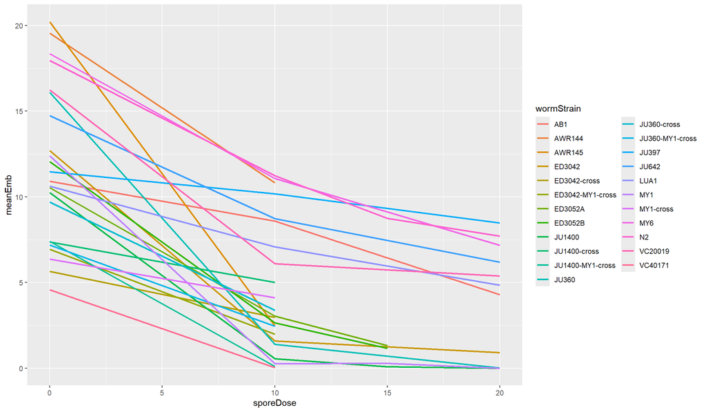

```r
# Pass the data on
split_embryo_long.df %>%

  # filter the data by spore type and timepoint
  filter(sporeStrain == "LUAm1", expTimepoint == 72) %>%

  # Group the data before summarising it
  group_by(wormStrain, sporeStrain, sporeDose) %>%

  # Summarise the data to get overall mean embryo counts
  summarize(meanEmb = mean(embryos)) %>%

  # Plot the data
  ggplot(data = .) +
    # Set the x and y axis variables, and how you want to colour the lines
    aes(x = sporeDose, y = meanEmb, colour = wormStrain) +
    # Set the type of visualization to a line graph
    geom_line(linewidth = 1)
```

## 6.2.0 Generate a scatterplot from `gapminder_long` data

Recall that our gapminder data carries some basic information such as GDP and life expectancy across multiple countries at multiple points in time. Let’s take a more wholesale look at this data and ask if there appears to be a relationship between life expectancy and GDP. We’ll focus just on one year of data to filter out other effects that might be dependent upon the year the data was collected.

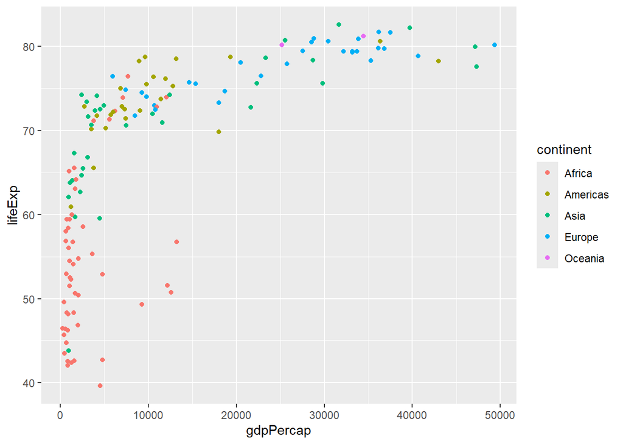

```r
# First filter gapminder_long
gapminder_long %>%
  filter(year == 2007) %>% # Take a look at just data from our last snapshot year: 2007

  # Pass the data to ggplot
  ggplot(data = .) +
    # Tell ggplot which columns to draw data from
    aes(x=gdpPercap, y = lifeExp, colour = continent) +
    # Define how you want the plot to be visualized
    geom_point()
```

With just a few lines of code, we can see that the overall trend suggests that life expectancy is positively correlated with GDP. It’s not always the case, from the look of some African countries, but that’s the general trend we see from a 2007 snapshot of data. Keep in mind that this data is now nearly 2 decades old! Next week we’ll learn even more about using `ggplot` to visualize our data and customize its presentation.

# 7.0.0 Class summary

That’s the end for our third class on R! You’ve made it through and we’ve learned about the following:

1. The tidy data format and philosophy.
2. Converting wide format data to long format.
3. Splitting multivariable columns
4. Grouping and summarising data.
5. Pivoting a multiple observation column to single observation variables
6. Returning data to a wide format
7. Joining/merging data across data sets
8. A small taste of visualizing data with `ggplot`

## 7.1.0 Submit your completed skeleton notebook (2% of final grade)

At the end of this lecture a Quercus assignment portal will be available to submit a **RMD** version of your completed skeletons from today (including the comprehension question answers!). These will be due one week later, before the next lecture. Each lecture skeleton is worth 2% of your final grade but a **bonus 0.5%** will also be awarded for submissions made within 24 hours from the end of lecture (ie 1300 hours the following day). To save your notebook:

1. From the RStudio Notebook in the lower right pane (**Files** tab), select the skeleton file checkbox (left-hand side of the file name)
2. Under the **More** button drop down, select the **Export** button and save to your hard drive.
3. Upload your RMD file to the Quercus skeleton portal.

[figure not shown]

## 7.2.0 Post-lecture assessment (6% of final grade)

Soon after the end of this lecture, a homework assignment will be available for you in [DataCamp](https://www.datacamp.com/). Your assignment is to complete two chapters from the **Reshaping Data with tidyr** course: Tidy data (950 points) and From wide to long and back (1300 points). This is a pass-fail assignment, and in order to pass you need to achieve a least 1,687 points (75%) of the total possible points. Note that when you take hints from the DataCamp chapter, it will reduce your total earned points for that chapter.

In order to properly assess your progress on DataCamp, at the end of each chapter, please print a PDF of the summary. You can do so by following these steps:

1. Navigate to the **`Learn`** section along the top menu bar of DataCamp. This will bring you to the various courses you have been assigned under **`My Assignments`**.
2. Click on your completed assignment and expand each **chapter** of the course by clicking on the **`VIEW CHAPTER DETAILS`** link. *Do this for all sections on the page*!
3. Carefully highlight/select the page starting with the course title (ie Introduction to R) and going to the end of the last section. **Avoid** using `ctrl + A` to highlight all of the visible text.
4. Print the page from your browser menu and save as a single PDF. In the options, be sure to print “*selection*” or you may not be able to print the full page. It should print out something like what follows, except with more chapter info.

[figure not shown]

You may need to take several screenshots if you cannot print it all in a single try. Submit the file(s) or a combined PDF for the homework to the assignment section of Quercus. By submitting your scores for each section, and chapter, we can keep track of your progress, identify knowledge gaps, and produce a standardized way for you to check on your assignment “grades” throughout the course.

You will have until 0959 hours on Tuesday, June 23rd to submit your assignment (right before the next lecture).

## 7.3.0 Acknowledgements

**Revision 1.0.0**: materials prepared in R Markdown by Oscar Montoya, M.Sc. *Bioinformatician, Education and Outreach, CAGEF.*

**Revision 1.1.0**: edited and prepared for **CSB1020H F LEC0142**, 09-2021 by Calvin Mok, Ph.D. *Bioinformatician, Education and Outreach, CAGEF.*

**Revision 1.1.1**: edited and prepared for **CSB1020H F LEC0142**, 09-2022 by Calvin Mok, Ph.D. *Bioinformatician, Education and Outreach, CAGEF.*

**Revision 1.1.2**: edited and prepared for **CSB1020H F LEC0142**, 09-2023 by Calvin Mok, Ph.D. *Bioinformatician, Education and Outreach, CAGEF.*

**Revision 1.2.0**: edited and prepared for **CSB1020H F LEC0142**, 09-2024 by Calvin Mok, Ph.D. *Bioinformatician, Education and Outreach, CAGEF.*

**Revision 1.2.1**: edited and prepared for **CSB1020H F LEC0142**, 09-2025 by Calvin Mok, Ph.D. *Bioinformatician, Education and Outreach, CAGEF.*

**Revision 1.2.2**: edited and prepared for **CSB1020H F LEC0142**, 06-2026 by Calvin Mok, Ph.D. *Bioinformatician, Education and Outreach, CAGEF.*

## 7.4.0 Your DataCamp academic subscription

This class is supported by DataCamp, the most intuitive learning platform for data science and analytics. Learn any time, anywhere and become an expert in R, Python, SQL, and more. DataCamp’s learn-by-doing methodology combines short expert videos and hands-on-the-keyboard exercises to help learners retain knowledge. DataCamp offers 350+ courses by expert instructors on topics such as importing data, data visualization, and machine learning. They?re constantly expanding their curriculum to keep up with the latest technology trends and to provide the best learning experience for all skill levels. Join over 6 million learners around the world and close your skills gap.

Your DataCamp academic subscription grants you free access to the DataCamp’s catalog for 6 months from the beginning of this course. You are free to look for additional tutorials and courses to help grow your skills for your data science journey. Learn more (literally!) at [DataCamp.com](https://learn.datacamp.com/).

[figure not shown]

## 7.5.0 Resources

https://github.com/wmhall/tidyr_lesson/blob/master/tidyr_lesson.md  
http://vita.had.co.nz/papers/tidy-data.pdf  
https://thinkr.fr/tidyverse-hadleyverse/  
http://stat545.com/bit001_dplyr-cheatsheet.html  
http://dplyr.tidyverse.org/articles/two-table.html

[figure not shown]